Student: Fernanda da Silva

# Exercises

**Exercise 0:** Create a new folder and notebook called **Intro-Data-Analysis-Pandas-Exercises** where you will perform all the exercises below. Make sure to copy any code you need from this notebook to that one. You will use that folder to create a new GitHub repo with the code, html, and slides as usual.

Done!

**Exercise 1:** Create a new dataframe `pop` with population data downloaded from Wikipedia. Make sure to clean the data so it can be used further.

```python
# Import display options for showing websites
from IPython.display import IFrame
url = 'https://en.wikipedia.org/wiki/List_of_countries_and_dependencies_by_population'
IFrame(url, width=800, height=400)
```

[interactive chart not shown]

```python
import pandas as pd
pop = pd.read_html(url, encoding='utf-8')[0]
pop
```

|  | Unnamed: 0 | Location | Population | % of world | Date | Source (official or from the United Nations) | Unnamed: 6 |
| --- | --- | --- | --- | --- | --- | --- | --- |
| 0 | NaN | World | 8099280000 | 100% | 6 Apr 2024 | UN projection[3] | NaN |
| 1 | [b] | China | 1409670000 | NaN | 31 Dec 2023 | Official estimate[5] | [c] |
| 2 | [b] | India | 1392329000 | NaN | 1 Jul 2023 | Official projection[6] | [d] |
| 3 | 3 | United States | 335893238 | NaN | 1 Jan 2024 | Official estimate[7] | [e] |
| 4 | 4 | Indonesia | 279118866 | NaN | 1 Jul 2023 | National annual projection[8] | NaN |
| ... | ... | ... | ... | ... | ... | ... | ... |
| 236 | NaN | Niue | 1689 | NaN | 11 Nov 2022 | 2022 Census [232] | NaN |
| 237 | NaN | Tokelau (NZ) | 1647 | NaN | 1 Jan 2019 | 2019 Census [233] | NaN |
| 238 | 195 | Vatican City | 764 | NaN | 26 Jun 2023 | Official figure[234] | [af] |
| 239 | NaN | Cocos (Keeling) Islands (Australia) | 593 | NaN | 30 Jun 2020 | 2021 Census[235] | NaN |
| 240 | NaN | Pitcairn Islands (UK) | 47 | NaN | 1 Jul 2021 | Official estimate[236] | NaN |

241 rows × 7 columns

**Exercise 2:** Merge the `isocodes` and `pop` dataframes.

```python
# Import display options for showing websites
url2 = 'https://en.wikipedia.org/wiki/List_of_ISO_3166_country_codes'

isocodes = pd.read_html(url2, encoding='utf-8')[0]
isocodes = isocodes.droplevel(0, axis=1)

mycols = isocodes.columns
mycols = [c[:c.find('[')].strip() for c in mycols]
mycols[0] = "Country"

isocodes.columns = mycols
isocodes.head()
```

|  | Country | World Factbook | Sovereignty | A-2 | A-3 | Num. | ISO 3166-2 | TLD |
| --- | --- | --- | --- | --- | --- | --- | --- | --- |
| 0 | Afghanistan | The Islamic Republic of Afghanistan | UN member | .mw-parser-output .monospaced{font-family:mono... | AFG | 004 | ISO 3166-2:AF | .af |
| 1 | Åland Islands | Åland | Finland | AX | ALA | 248 | ISO 3166-2:AX | .ax |
| 2 | Albania | The Republic of Albania | UN member | AL | ALB | 008 | ISO 3166-2:AL | .al |
| 3 | Algeria | The People's Democratic Republic of Algeria | UN member | DZ | DZA | 012 | ISO 3166-2:DZ | .dz |
| 4 | American Samoa | The Territory of American Samoa | United States | AS | ASM | 016 | ISO 3166-2:AS | .as |

```python
isopop = isocodes.merge(pop, left_on='Country', right_on='Location')
isopop
```

|  | Country | World Factbook | Sovereignty | A-2 | A-3 | Num. | ISO 3166-2 | TLD | Unnamed: 0 | Location | Population | % of world | Date | Source (official or from the United Nations) | Unnamed: 6 |
| --- | --- | --- | --- | --- | --- | --- | --- | --- | --- | --- | --- | --- | --- | --- | --- |
| 0 | Afghanistan | The Islamic Republic of Afghanistan | UN member | .mw-parser-output .monospaced{font-family:mono... | AFG | 004 | ISO 3166-2:AF | .af | 41 | Afghanistan | 34262840 | NaN | 1 Jan 2023 | Official estimate[45] | NaN |
| 1 | Albania | The Republic of Albania | UN member | AL | ALB | 008 | ISO 3166-2:AL | .al | 137 | Albania | 2761785 | NaN | 1 Jan 2023 | Official estimate[143] | NaN |
| 2 | Algeria | The People's Democratic Republic of Algeria | UN member | DZ | DZA | 012 | ISO 3166-2:DZ | .dz | 33 | Algeria | 45400000 | NaN | 1 Jan 2022 | Official estimate[37] | NaN |
| 3 | Andorra | The Principality of Andorra | UN member | AD | AND | 020 | ISO 3166-2:AD | .ad | 185 | Andorra | 85101 | NaN | 31 Dec 2023 | Official estimate[201] | NaN |
| 4 | Angola | The Republic of Angola | UN member | AO | AGO | 024 | ISO 3166-2:AO | .ao | 42 | Angola | 34094077 | NaN | 1 Jun 2023 | National annual projection[46] | NaN |
| ... | ... | ... | ... | ... | ... | ... | ... | ... | ... | ... | ... | ... | ... | ... | ... |
| 150 | Uzbekistan | The Republic of Uzbekistan | UN member | UZ | UZB | 860 | ISO 3166-2:UZ | .uz | 40 | Uzbekistan | 36599764 | NaN | 1 Oct 2023 | National quarterly estimate[44] | NaN |
| 151 | Vanuatu | The Republic of Vanuatu | UN member | VU | VUT | 548 | ISO 3166-2:VU | .vu | 173 | Vanuatu | 301295 | NaN | 1 Jul 2021 | National annual projection[184] | NaN |
| 152 | Yemen | The Republic of Yemen | UN member | YE | YEM | 887 | ISO 3166-2:YE | .ye | 47 | Yemen | 31888698 | NaN | 1 Jul 2022 | Official estimate[51] | NaN |
| 153 | Zambia | The Republic of Zambia | UN member | ZM | ZMB | 894 | ISO 3166-2:ZM | .zm | 64 | Zambia | 19610769 | NaN | 14 Sep 2022 | 2022 census result[69] | NaN |
| 154 | Zimbabwe | The Republic of Zimbabwe | UN member | ZW | ZWE | 716 | ISO 3166-2:ZW | .zw | 73 | Zimbabwe | 15178979 | NaN | 20 Apr 2022 | 2022 census result[77] | NaN |

155 rows × 15 columns

**Exercise 3:** Merge the dataframes we have created so far to have a unique dataframe that has ISO codes, GDP per capita, and population data.

```python
#url3 = 'https://en.wikipedia.org/wiki/List_of_countries_by_GDP_(PPP)_per_capita'
url3 = 'https://en.wikipedia.org/wiki/List_of_countries_by_GDP_(nominal)_per_capita'
gdppc_wiki = pd.read_html(url3, encoding='utf-8')[1]

# Cleaning the data
gdppc_wiki.columns = ['Country', 'UN Region', 'gdppc_IMF', 'year_IMF',
                      'gdppc_WB', 'year_WB', 'gdppc_CIA', 'year_CIA']
gdppc_wiki.head()
```

|  | Country | UN Region | gdppc_IMF | year_IMF | gdppc_WB | year_WB | gdppc_CIA | year_CIA |
| --- | --- | --- | --- | --- | --- | --- | --- | --- |
| 0 | Monaco | Europe | — | — | 234317 | 2021 | 234317 | 2021 |
| 1 | Liechtenstein | Europe | — | — | 184083 | 2021 | 169260 | 2021 |
| 2 | Luxembourg | Europe | 135605 | 2023 | 126426 | 2022 | 133745 | 2021 |
| 3 | Bermuda | Americas | — | — | 118846 | 2022 | 112653 | 2021 |
| 4 | Ireland | Europe | 112248 | 2023 | 104039 | 2022 | 101109 | 2021 |

```python
gdppc_wiki.dtypes
```

```
Country      object
UN Region    object
gdppc_IMF    object
year_IMF     object
gdppc_WB     object
year_WB      object
gdppc_CIA    object
year_CIA     object
dtype: object
```

```python
for c in gdppc_wiki.columns[2:-1]:
    if gdppc_wiki[c].dtype=='O':
        gdppc_wiki[c] = pd.to_numeric(gdppc_wiki[c].str.replace('—', 'nan'), errors='coerce')
        if c.startswith('year'):
            gdppc_wiki[c] = gdppc_wiki[c].astype('Int64')
```

```python
gdppc_wiki.dtypes
```

```
Country       object
UN Region     object
gdppc_IMF    float64
year_IMF       Int64
gdppc_WB     float64
year_WB        Int64
gdppc_CIA    float64
year_CIA      object
dtype: object
```

```python
# Removing *:
gdppc_wiki['Country'] = gdppc_wiki['Country'].str.replace('*', '')
gdppc_wiki.head()
```

|  | Country | UN Region | gdppc_IMF | year_IMF | gdppc_WB | year_WB | gdppc_CIA | year_CIA |
| --- | --- | --- | --- | --- | --- | --- | --- | --- |
| 0 | Monaco | Europe | NaN | <NA> | 234317.0 | 2021 | 234317.0 | 2021 |
| 1 | Liechtenstein | Europe | NaN | <NA> | 184083.0 | 2021 | 169260.0 | 2021 |
| 2 | Luxembourg | Europe | 135605.0 | 2023 | 126426.0 | 2022 | 133745.0 | 2021 |
| 3 | Bermuda | Americas | NaN | <NA> | 118846.0 | 2022 | 112653.0 | 2021 |
| 4 | Ireland | Europe | 112248.0 | 2023 | 104039.0 | 2022 | 101109.0 | 2021 |

```python
merged = isopop.merge(gdppc_wiki, left_on='Location', right_on='Country')
merged
```

|  | Country_x | World Factbook | Sovereignty | A-2 | A-3 | Num. | ISO 3166-2 | TLD | Unnamed: 0 | Location | ... | Source (official or from the United Nations) | Unnamed: 6 | Country_y | UN Region | gdppc_IMF | year_IMF | gdppc_WB | year_WB | gdppc_CIA | year_CIA |
| --- | --- | --- | --- | --- | --- | --- | --- | --- | --- | --- | --- | --- | --- | --- | --- | --- | --- | --- | --- | --- | --- |
| 0 | Afghanistan | The Islamic Republic of Afghanistan | UN member | .mw-parser-output .monospaced{font-family:mono... | AFG | 004 | ISO 3166-2:AF | .af | 41 | Afghanistan | ... | Official estimate[45] | NaN | Afghanistan | Asia | 443.0 | 2021 | 364.0 | 2022 | 373.0 | 2021 |
| 1 | Albania | The Republic of Albania | UN member | AL | ALB | 008 | ISO 3166-2:AL | .al | 137 | Albania | ... | Official estimate[143] | NaN | Albania | Europe | 8057.0 | 2023 | 6803.0 | 2022 | 6396.0 | 2021 |
| 2 | Algeria | The People's Democratic Republic of Algeria | UN member | DZ | DZA | 012 | ISO 3166-2:DZ | .dz | 33 | Algeria | ... | Official estimate[37] | NaN | Algeria | Africa | 4875.0 | 2023 | 4274.0 | 2022 | 3700.0 | 2021 |
| 3 | Andorra | The Principality of Andorra | UN member | AD | AND | 020 | ISO 3166-2:AD | .ad | 185 | Andorra | ... | Official estimate[201] | NaN | Andorra | Europe | 44107.0 | 2023 | 41993.0 | 2022 | 42066.0 | 2021 |
| 4 | Angola | The Republic of Angola | UN member | AO | AGO | 024 | ISO 3166-2:AO | .ao | 42 | Angola | ... | National annual projection[46] | NaN | Angola | Africa | 2550.0 | 2023 | 2999.0 | 2022 | 2258.0 | 2021 |
| ... | ... | ... | ... | ... | ... | ... | ... | ... | ... | ... | ... | ... | ... | ... | ... | ... | ... | ... | ... | ... | ... |
| 149 | Uzbekistan | The Republic of Uzbekistan | UN member | UZ | UZB | 860 | ISO 3166-2:UZ | .uz | 40 | Uzbekistan | ... | National quarterly estimate[44] | NaN | Uzbekistan | Asia | 2509.0 | 2023 | 2255.0 | 2022 | 2032.0 | 2021 |
| 150 | Vanuatu | The Republic of Vanuatu | UN member | VU | VUT | 548 | ISO 3166-2:VU | .vu | 173 | Vanuatu | ... | National annual projection[184] | NaN | Vanuatu | Oceania | 3492.0 | 2023 | 3010.0 | 2022 | 3073.0 | 2021 |
| 151 | Yemen | The Republic of Yemen | UN member | YE | YEM | 887 | ISO 3166-2:YE | .ye | 47 | Yemen | ... | Official estimate[51] | NaN | Yemen | Asia | 618.0 | 2023 | 702.0 | 2018 | 302.0 | 2021 |
| 152 | Zambia | The Republic of Zambia | UN member | ZM | ZMB | 894 | ISO 3166-2:ZM | .zm | 64 | Zambia | ... | 2022 census result[69] | NaN | Zambia | Africa | 1486.0 | 2023 | 1488.0 | 2022 | 1095.0 | 2021 |
| 153 | Zimbabwe | The Republic of Zimbabwe | UN member | ZW | ZWE | 716 | ISO 3166-2:ZW | .zw | 73 | Zimbabwe | ... | 2022 census result[77] | NaN | Zimbabwe | Africa | 2006.0 | 2023 | 1267.0 | 2022 | 1508.0 | 2021 |

154 rows × 23 columns

**Exercise 4:** Use the `os` package to create folders to export data and figures. Since you will be using the names of these folders a lot, save their names in variables called `path`, `pathout`, and `pathgraphs`, where `path = './data/'`, `pathout = './data/'`, and `pathgraphs = './graphs/'`

```python
import os

# Define folder paths
path = './data/'
pathout = './data/'
pathgraphs = './graphs/'

# Check if the folders exist, if not, create them
if not os.path.exists(path):
    os.makedirs(path)

if not os.path.exists(pathout):
    os.makedirs(pathout)

if not os.path.exists(pathgraphs):
    os.makedirs(pathgraphs)
```

**Exercise 5:** Save the dataframe created in Exercise 3 as a **CSV, XLSX, and Stata** file into the `pathout` folder. Use a variable called `filename = 'Wiki_Data'` so you can use similar code to save all file types. Notice only the filetype will change. **Hint:** If you get econding errors for Stata, use the keyword `version=118` inside the `to_stata` function.

```python
# Define the filename
filename = 'Wiki_Data'

# Save as CSV
csv_file = os.path.join(pathout, f'{filename}.csv')
merged.to_csv(csv_file, index=False)

# Save as XLSX
xlsx_file = os.path.join(pathout, f'{filename}.xlsx')
merged.to_excel(xlsx_file, index=False)

# Save as Stata
stata_file = os.path.join(pathout, f'{filename}.dta')
merged.to_stata(stata_file, version=118)
```

[output not shown]

[output not shown]

[output cut: 63 more lines]

[output not shown]

**Exercise 6:** Create plots showing the relation between GDP per capita and Population. Create all 4 types of possible regression plots (levels-levels, levels-logs, logs-levels, logs-logs) and save them as **PNG, PDF, and JPG** files. Make sure to save them in the folder you created for **graphs**

```python
import numpy as np
import matplotlib.pyplot as plt

df = pd.DataFrame(merged)

filename_prefix = 'GDP_vs_Population'
```

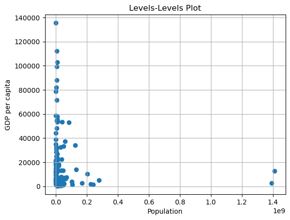

```python
# Levels-Levels plot
plt.scatter(df['Population'], df['gdppc_IMF'])
plt.xlabel('Population')
plt.ylabel('GDP per capita')
plt.title('Levels-Levels Plot')
plt.grid(True)
plt.savefig(os.path.join(pathgraphs, f'{filename_prefix}_levels_levels.png'))
plt.savefig(os.path.join(pathgraphs, f'{filename_prefix}_levels_levels.pdf'))
plt.savefig(os.path.join(pathgraphs, f'{filename_prefix}_levels_levels.jpg'))
plt.show()
```

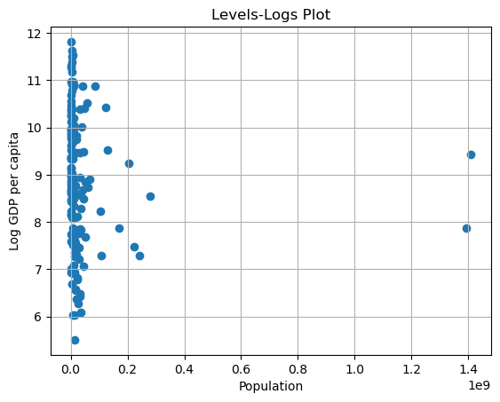

```python
# Levels-Logs plot
plt.scatter(df['Population'], np.log(df['gdppc_IMF']))
plt.xlabel('Population')
plt.ylabel('Log GDP per capita')
plt.title('Levels-Logs Plot')
plt.grid(True)
plt.savefig(os.path.join(pathgraphs, f'{filename_prefix}_levels_logs.png'))
plt.savefig(os.path.join(pathgraphs, f'{filename_prefix}_levels_logs.pdf'))
plt.savefig(os.path.join(pathgraphs, f'{filename_prefix}_levels_logs.jpg'))
plt.show()
```

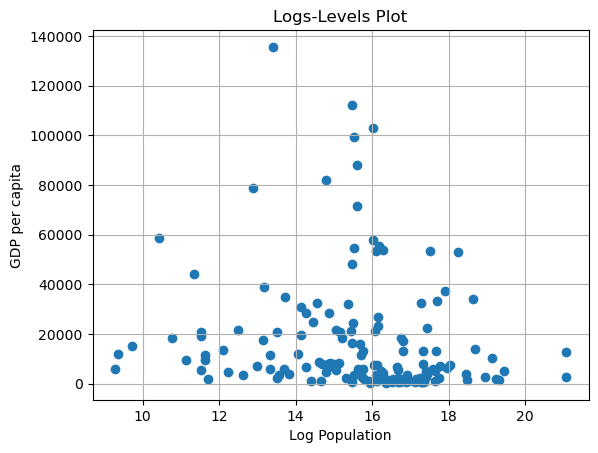

```python
# Logs-Levels plot
plt.scatter(np.log(df['Population']), df['gdppc_IMF'])
plt.xlabel('Log Population')
plt.ylabel('GDP per capita')
plt.title('Logs-Levels Plot')
plt.grid(True)
plt.savefig(os.path.join(pathgraphs, f'{filename_prefix}_logs_levels.png'))
plt.savefig(os.path.join(pathgraphs, f'{filename_prefix}_logs_levels.pdf'))
plt.savefig(os.path.join(pathgraphs, f'{filename_prefix}_logs_levels.jpg'))
plt.show()
```

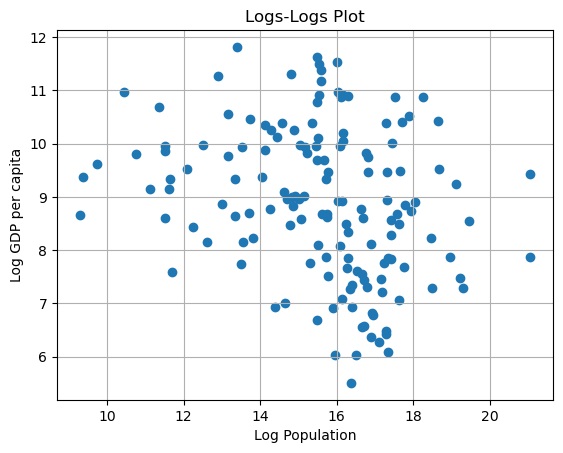

```python
# Logs-Logs plot
plt.scatter(np.log(df['Population']), np.log(df['gdppc_IMF']))
plt.xlabel('Log Population')
plt.ylabel('Log GDP per capita')
plt.title('Logs-Logs Plot')
plt.grid(True)
plt.savefig(os.path.join(pathgraphs, f'{filename_prefix}_logs_logs.png'))
plt.savefig(os.path.join(pathgraphs, f'{filename_prefix}_logs_logs.pdf'))
plt.savefig(os.path.join(pathgraphs, f'{filename_prefix}_logs_logs.jpg'))
plt.show()
```

**Exercise 7:** Create plots showing the relation between GDP per capita and Population Growth. Create all 4 types of possible regression plots (levels-levels, levels-logs, logs-levels, logs-logs) and save them as **PNG, PDF, and JPG** files. Make sure to save them in the folder you created for **graphs**

It is the same exercise as above.

[figure not shown]

Created in Deepnote